# Spatial data: interpolation, simulation, averaging

### Variogram, covariogram, auto-correlogram

```r
library(sf)
demo(meuse_sf, ask = FALSE) # load meuse dataset
```

```
##
##
##  demo(meuse_sf)
##  ---- ~~~~~~~~
##
## > data(meuse, package = "sp") # load data.frame from sp
##
## > library(sf)
##
## > meuse_sf = st_as_sf(meuse, coords = c("x", "y"), crs = 28992)
##
## > meuse_sf[1:5,]
## Simple feature collection with 5 features and 12 fields
## geometry type:  POINT
## dimension:      XY
## bbox:           xmin: 181025 ymin: 333330 xmax: 181307 ymax: 333611
## epsg (SRID):    28992
## proj4string:    +proj=sterea +lat_0=52.15616055555555 +lon_0=5.38763888888889 +k=0.9999079 +x_0=155000 +y_0=463000 +ellps=bessel +towgs84=565.2369,50.0087,465.658,-0.406857,0.350733,-1.87035,4.0812 +units=m +no_defs
##   cadmium copper lead zinc  elev       dist   om ffreq soil lime landuse
## 1    11.7     85  299 1022 7.909 0.00135803 13.6     1    1    1      Ah
## 2     8.6     81  277 1141 6.983 0.01222430 14.0     1    1    1      Ah
## 3     6.5     68  199  640 7.800 0.10302900 13.0     1    1    1      Ah
## 4     2.6     81  116  257 7.655 0.19009400  8.0     1    2    0      Ga
## 5     2.8     48  117  269 7.480 0.27709000  8.7     1    2    0      Ah
##   dist.m              geometry
## 1     50 POINT (181072 333611)
## 2     30 POINT (181025 333558)
## 3    150 POINT (181165 333537)
## 4    270 POINT (181298 333484)
## 5    380 POINT (181307 333330)
##
## > summary(meuse_sf[1:5,])
##     cadmium          copper          lead            zinc
##  Min.   : 2.60   Min.   :48.0   Min.   :116.0   Min.   : 257.0
##  1st Qu.: 2.80   1st Qu.:68.0   1st Qu.:117.0   1st Qu.: 269.0
##  Median : 6.50   Median :81.0   Median :199.0   Median : 640.0
##  Mean   : 6.44   Mean   :72.6   Mean   :201.6   Mean   : 665.8
##  3rd Qu.: 8.60   3rd Qu.:81.0   3rd Qu.:277.0   3rd Qu.:1022.0
##  Max.   :11.70   Max.   :85.0   Max.   :299.0   Max.   :1141.0
##
##       elev            dist                om        ffreq soil  lime
##  Min.   :6.983   Min.   :0.001358   Min.   : 8.00   1:5   1:3   0:2
##  1st Qu.:7.480   1st Qu.:0.012224   1st Qu.: 8.70   2:0   2:2   1:3
##  Median :7.655   Median :0.103029   Median :13.00   3:0   3:0
##  Mean   :7.565   Mean   :0.116759   Mean   :11.46
##  3rd Qu.:7.800   3rd Qu.:0.190094   3rd Qu.:13.60
##  Max.   :7.909   Max.   :0.277090   Max.   :14.00
##
##     landuse      dist.m             geometry
##  Ah     :4   Min.   : 30   POINT        :5
##  Ga     :1   1st Qu.: 50   epsg:28992   :0
##  Aa     :0   Median :150   +proj=ster...:0
##  Ab     :0   Mean   :176
##  Ag     :0   3rd Qu.:270
##  Am     :0   Max.   :380
##  (Other):0
```

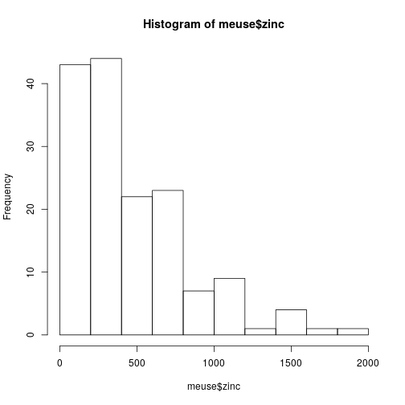

```r
library(gstat)
hist(meuse$zinc)
```

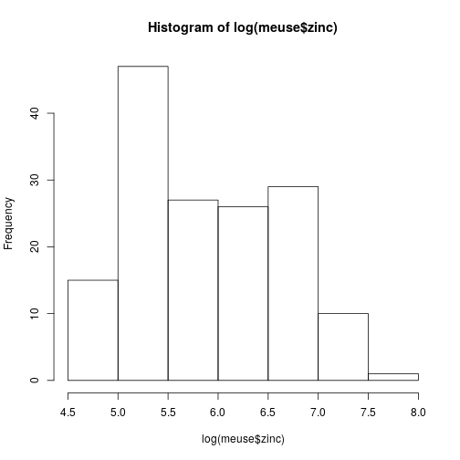

```r
hist(log(meuse$zinc))
```

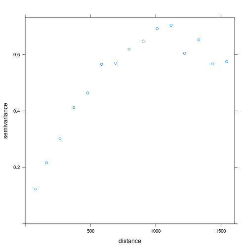

```r
plot(variogram(log(zinc)~1, meuse_sf))
```

How can we relate the variogram to the autocorrelogram?

1. There is no scaling to \([-1,1]\) (this scaling converts covariances to correlation)
2. Variogram values are strictly positive (mean squares)
3. Variogram increase with distance (with decreasing correlation)

The variogram and covariogram relate through \[\gamma(h) = C(0) - C(h)\] with \(C(h)\) the covariogram of the process:

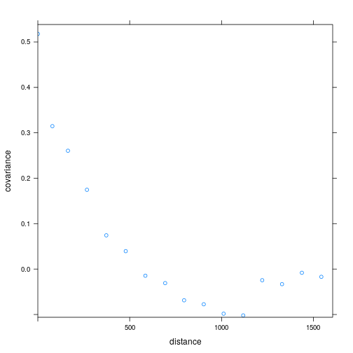

```r
plot(variogram(log(zinc)~1, meuse_sf, covariogram = TRUE))
```

### What to choose as lag distance?

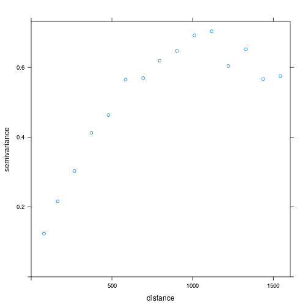

```r
plot(variogram(log(zinc)~1, meuse_sf))
```

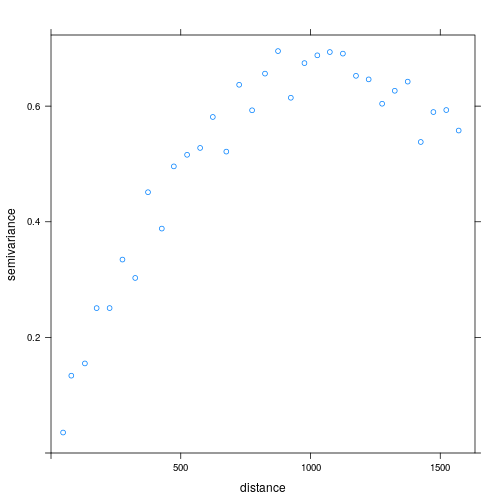

```r
plot(variogram(log(zinc)~1, meuse_sf, width = 50))
```

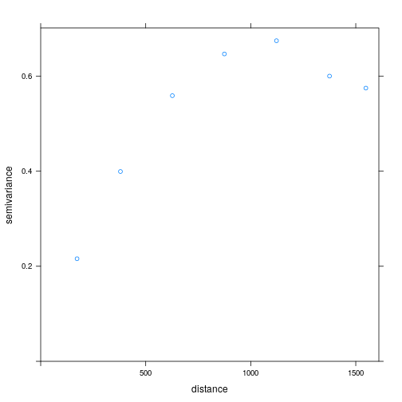

```r
plot(variogram(log(zinc)~1, meuse_sf, width = 250))
```

All still somewhat acceptible; things get weirder when

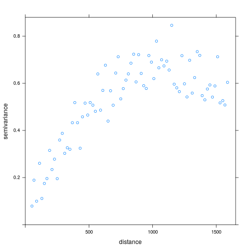

```r
plot(variogram(log(zinc)~1, meuse_sf, width = 20))
```

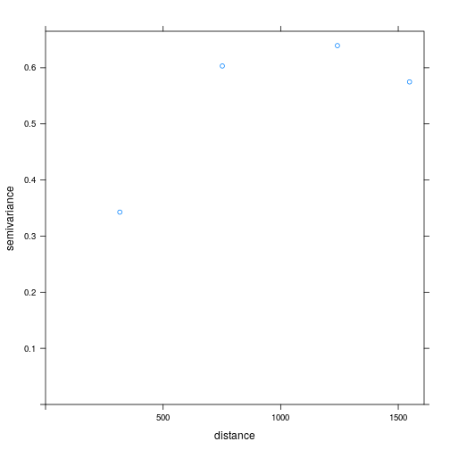

```r
plot(variogram(log(zinc)~1, meuse_sf, width = 500))
```

### Variogram model

For further analysis, we need a variogram *model*, a parametric model \(\gamma(h)\) that gives semivariance (and hence: covariance, autocorrelation) values for *every* value of \(h\):

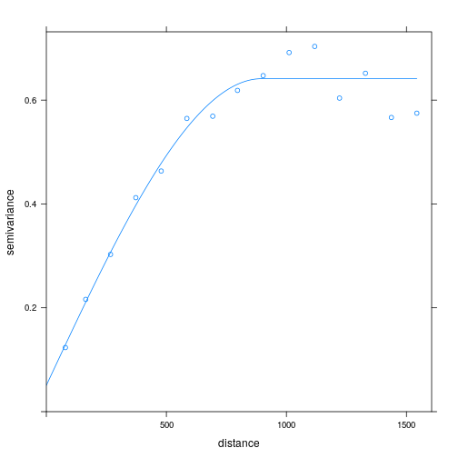

```r
v = variogram(log(zinc)~1, meuse_sf)
f = fit.variogram(v, vgm(1, "Sph", 300, 1))
plot(v, f)
```

```r
f
```

```
##   model      psill  range
## 1   Nug 0.05065547   0.00
## 2   Sph 0.59060085 896.97
```

The reason for this is that we would like to be able to make a prediction (interpolation) for *any* location, and this involves *any* distance(s) to observation values.

Compare: for time series we typically predict (forecast) \(y_{t+1\delta}, y_{t+2\delta},…\). Would we want to predict (forecast) values for values *inbetween*, like \(y_{t+0.33\delta}\) or \(y_{t+7.51\delta}\), then we'd need autocorrelations for these non-multiples of the time interval \(\delta\), and we'd need to *interpolate* (model) the autocorrellogram.

### Positive definite

Models we fit to a covariogram (or autocorrelation) need to be *positive definite*. This means that for an arbitrary set of points \(p_1,…,p_2\) the covariance matrix \(C\) of the these points has the following property \[a' C a > 0\] for non-zero but otherwise arbitrarily chosen weights coefficients \(a\). This guarantees, amongst others, that prediction variances are non-negative.

For variograms, signs flip, and we require *negative definite* functions, to the same effect.

It is easy to go wrong here, for instance the break-line model:

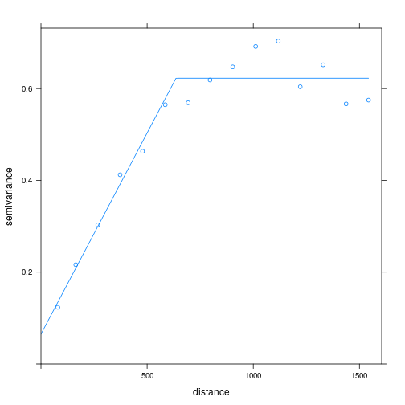

```r
f0 = fit.variogram(v, vgm(1, "Lin", 700, 1))
plot(v, f0)
```

does have this property for points in 1, but not in 2 or more dimensions!

### Coordinates in lat/long

- coordinates on the sphere (geographic, geodetic coordinates) are expressed as angles (longitude, latitude), and not as distances
- hence, to compute distances between points (\(h\)), we cannot use Euclides' formula \(\sqrt{(x_1-x_2)^2+(y_1-y_2)^2}\)
- R can deal with this automatically, but you need to tell it!

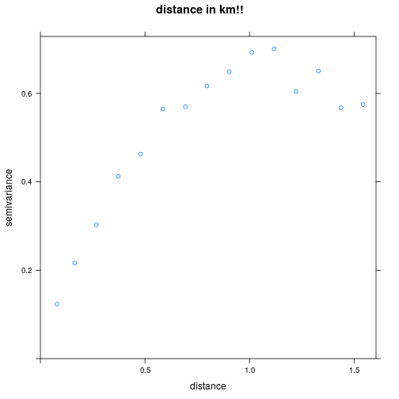

```r
meuse_ll = st_transform(meuse_sf, "+proj=longlat +datum=WGS84")
plot(variogram(log(zinc)~1, meuse_ll), main = "distance in km!!")
```

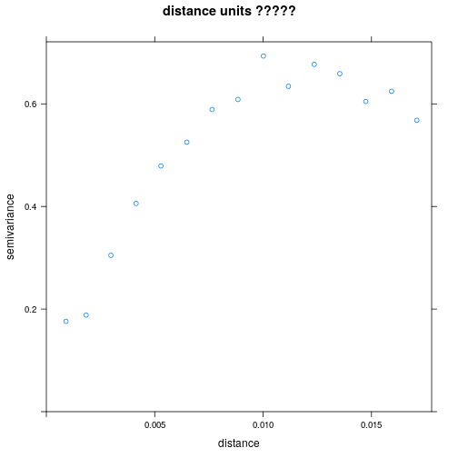

```r
st_crs(meuse_ll) = NA # remove CRS
plot(variogram(log(zinc)~1, meuse_ll), main = "distance units ?????")
```

More in detail:

```r
(pts = rbind(c(0,0), c(1,0), c(0,1)))
```

```
##      [,1] [,2]
## [1,]    0    0
## [2,]    1    0
## [3,]    0    1
```

```r
as.matrix(dist(pts))
```

```
##   1        2        3
## 1 0 1.000000 1.000000
## 2 1 0.000000 1.414214
## 3 1 1.414214 0.000000
```

```r
df = data.frame(pts)
names(df) = c("x", "y")
st_distance(st_as_sf(df, coords = c("x", "y"), crs = NA))
```

```
##      [,1]     [,2]     [,3]
## [1,]    0 1.000000 1.000000
## [2,]    1 0.000000 1.414214
## [3,]    1 1.414214 0.000000
```

```r
st_distance(st_as_sf(df, coords = c("x", "y"), crs = "+proj=longlat"))
```

```
## Units: [m]
##          [,1]     [,2]     [,3]
## [1,]      0.0 111319.5 110574.4
## [2,] 111319.5      0.0 156899.6
## [3,] 110574.4 156899.6      0.0
```

```r
(pts_here = rbind(c(7,52), c(8,52), c(7,53)))
```

```
##      [,1] [,2]
## [1,]    7   52
## [2,]    8   52
## [3,]    7   53
```

```r
df_here = data.frame(pts_here)
names(df_here) = c("x", "y")
st_distance(st_as_sf(df_here, coords = c("x", "y"), crs = NA))
```

```
##      [,1]     [,2]     [,3]
## [1,]    0 1.000000 1.000000
## [2,]    1 0.000000 1.414214
## [3,]    1 1.414214 0.000000
```

```r
st_distance(st_as_sf(df_here, coords = c("x", "y"), crs = "+proj=longlat"))
```

```
## Units: [m]
##           [,1]      [,2]     [,3]
## [1,]      0.00  68677.47 111276.8
## [2,]  68677.47      0.00 130359.3
## [3,] 111276.83 130359.29      0.0
```

Note that:

- Euclidian distance calculations are insensitive for swapping x and y
- Geodetical distance calculations are **NOT** insenstive to axis swapping
- it is of crucial importance to *not* mix up longitude and latitude
- R adopts this order: 1. longitude, 2. latitude (think: x, y)

```r
st_distance(st_as_sf(df_here, coords = c("x", "y"), crs = NA))
```

```
##      [,1]     [,2]     [,3]
## [1,]    0 1.000000 1.000000
## [2,]    1 0.000000 1.414214
## [3,]    1 1.414214 0.000000
```

```r
st_distance(st_as_sf(df_here, coords = c("y", "x"), crs = NA))
```

```
##      [,1]     [,2]     [,3]
## [1,]    0 1.000000 1.000000
## [2,]    1 0.000000 1.414214
## [3,]    1 1.414214 0.000000
```

```r
st_distance(st_as_sf(df_here, coords = c("x", "y"), crs = "+proj=longlat"))
```

```
## Units: [m]
##           [,1]      [,2]     [,3]
## [1,]      0.00  68677.47 111276.8
## [2,]  68677.47      0.00 130359.3
## [3,] 111276.83 130359.29      0.0
```

```r
st_distance(st_as_sf(df_here, coords = c("y", "x"), crs = "+proj=longlat"))
```

```
## Units: [m]
##          [,1]     [,2]     [,3]
## [1,]      0.0 110593.2 110495.2
## [2,] 110593.2      0.0 156246.0
## [3,] 110495.2 156246.0      0.0
```